# airbnb

## imoport pkgs

```python
import numpy as np
import pandas as pd
import matplotlib.pyplot as plt
from sklearn.linear_model import LinearRegression
from sklearn.model_selection import train_test_split
from sklearn.metrics import r2_score, mean_squared_error
import seaborn as sns
```

## Load Data

```python
## load data
df_settle_clendar_raw = pd.read_csv('data/seattle/calendar.csv')
df_settle_listings_raw = pd.read_csv('data/seattle/listings.csv')
df_settle_reviews_raw = pd.read_csv('data/seattle/reviews.csv')

df_boston_airbnb_calendar_raw = pd.read_csv('data/boston-airbnb-open-data/calendar.csv')
df_boston_airbnb_listings_raw = pd.read_csv('data/boston-airbnb-open-data/listings.csv')
df_boston_airbnb_reviews_raw = pd.read_csv('data/boston-airbnb-open-data/reviews.csv')
```

## Explore Data

### df_settle_clendar_raw

```python
info_dic = {'Feature':pd.Series(['listing_id','date','available','price']),
            'Meaning':pd.Series(['清单id','日期','是否有效','价格']),
           }
df_settle_clendar_raw_info = pd.DataFrame(info_dic)
df_settle_clendar_raw_info
```

|  | Feature | Meaning |
| --- | --- | --- |
| 0 | listing_id | 清单id |
| 1 | date | 日期 |
| 2 | available | 是否有效 |
| 3 | price | 价格 |

```python
df_settle_clendar_raw.info()
```

```
<class 'pandas.core.frame.DataFrame'>
RangeIndex: 1393570 entries, 0 to 1393569
Data columns (total 4 columns):
listing_id    1393570 non-null int64
date          1393570 non-null object
available     1393570 non-null object
price         934542 non-null object
dtypes: int64(1), object(3)
memory usage: 42.5+ MB
```

```python
df_settle_clendar_raw.head()
```

|  | listing_id | date | available | price |
| --- | --- | --- | --- | --- |
| 0 | 241032 | 2016-01-04 | t | $85.00 |
| 1 | 241032 | 2016-01-05 | t | $85.00 |
| 2 | 241032 | 2016-01-06 | f | NaN |
| 3 | 241032 | 2016-01-07 | f | NaN |
| 4 | 241032 | 2016-01-08 | f | NaN |

```python
## get all the NaN values in price
df_settle_clendar_raw[df_settle_clendar_raw['price'].isnull()].head()
```

|  | listing_id | date | available | price |
| --- | --- | --- | --- | --- |
| 2 | 241032 | 2016-01-06 | f | NaN |
| 3 | 241032 | 2016-01-07 | f | NaN |
| 4 | 241032 | 2016-01-08 | f | NaN |
| 5 | 241032 | 2016-01-09 | f | NaN |
| 6 | 241032 | 2016-01-10 | f | NaN |

After explore the NaN value of df_settle_clendar_raw,it only appear in unavailable line.So we don't need to drop it.

### df_settle_listings_raw

- The table of df_seattle_listings_raw's meaning:

| Feature | Meaning | Relation |
| --- | --- | --- |
| id | id | PK |
| listing_url | 清单url |  |
| scrape_id |  |  |
| last_scraped |  |  |
| name | 清单名 |  |
| summary | 摘要 |  |
| space | 空间 |  |
| description | 描述 |  |
| experiences_offered | 体验 |  |
| neighborhood_overview | 邻居 |  |
| notes | 记录 |  |
| transit | 中转 |  |
| thumbnail_url | 简介url |  |
| medium_url | 视频url |  |
| picture_url | 图片url |  |
| xl_picture_url | x1图片url |  |
| host_id | 租客id |  |
| host_url | 租客url |  |
| host_name | 租客姓名 |  |
| host_since | 租客 |  |
| host_location | 租客地址 |  |
| host_about | 租客信息 |  |
| host_response_time | 租客响应时间 |  |
| host_response_rate | 租客响应率 |  |
| host_acceptance_rate | 租客验收率 |  |
| host_is_superhost | 租客是会员 |  |
| host_thumbnail_url | 租客简介url |  |
| host_picture_url | 租客图片url |  |
| host_neighbourhood | 租客邻居 |  |
| host_listings_count | 租客清单数 |  |

[output cut: 62 more lines]

```python
df_settle_listings_raw.head()
```

|  | id | listing_url | scrape_id | last_scraped | name | summary | space | description | experiences_offered | neighborhood_overview | ... | review_scores_value | requires_license | license | jurisdiction_names | instant_bookable | cancellation_policy | require_guest_profile_picture | require_guest_phone_verification | calculated_host_listings_count | reviews_per_month |
| --- | --- | --- | --- | --- | --- | --- | --- | --- | --- | --- | --- | --- | --- | --- | --- | --- | --- | --- | --- | --- | --- |
| 0 | 241032 | https://www.airbnb.com/rooms/241032 | 20160104002432 | 2016-01-04 | Stylish Queen Anne Apartment | NaN | Make your self at home in this charming one-be... | Make your self at home in this charming one-be... | none | NaN | ... | 10.0 | f | NaN | WASHINGTON | f | moderate | f | f | 2 | 4.07 |
| 1 | 953595 | https://www.airbnb.com/rooms/953595 | 20160104002432 | 2016-01-04 | Bright & Airy Queen Anne Apartment | Chemically sensitive? We've removed the irrita... | Beautiful, hypoallergenic apartment in an extr... | Chemically sensitive? We've removed the irrita... | none | Queen Anne is a wonderful, truly functional vi... | ... | 10.0 | f | NaN | WASHINGTON | f | strict | t | t | 6 | 1.48 |
| 2 | 3308979 | https://www.airbnb.com/rooms/3308979 | 20160104002432 | 2016-01-04 | New Modern House-Amazing water view | New modern house built in 2013. Spectacular s... | Our house is modern, light and fresh with a wa... | New modern house built in 2013. Spectacular s... | none | Upper Queen Anne is a charming neighborhood fu... | ... | 10.0 | f | NaN | WASHINGTON | f | strict | f | f | 2 | 1.15 |
| 3 | 7421966 | https://www.airbnb.com/rooms/7421966 | 20160104002432 | 2016-01-04 | Queen Anne Chateau | A charming apartment that sits atop Queen Anne... | NaN | A charming apartment that sits atop Queen Anne... | none | NaN | ... | NaN | f | NaN | WASHINGTON | f | flexible | f | f | 1 | NaN |
| 4 | 278830 | https://www.airbnb.com/rooms/278830 | 20160104002432 | 2016-01-04 | Charming craftsman 3 bdm house | Cozy family craftman house in beautiful neighb... | Cozy family craftman house in beautiful neighb... | Cozy family craftman house in beautiful neighb... | none | We are in the beautiful neighborhood of Queen ... | ... | 9.0 | f | NaN | WASHINGTON | f | strict | f | f | 1 | 0.89 |

5 rows × 92 columns

```python
df_settle_listings_raw.loc[0]
```

```
id                                                                             241032
listing_url                                       https://www.airbnb.com/rooms/241032
scrape_id                                                              20160104002432
last_scraped                                                               2016-01-04
name                                                     Stylish Queen Anne Apartment
summary                                                                           NaN
space                               Make your self at home in this charming one-be...
description                         Make your self at home in this charming one-be...
experiences_offered                                                              none
neighborhood_overview                                                             NaN
notes                                                                             NaN
transit                                                                           NaN
thumbnail_url                                                                     NaN
medium_url                                                                        NaN
picture_url                         https://a1.muscache.com/ac/pictures/67560560/c...
xl_picture_url                                                                    NaN
host_id                                                                        956883
host_url                                     https://www.airbnb.com/users/show/956883
host_name                                                                       Maija
host_since                                                                 2011-08-11
host_location                                      Seattle, Washington, United States
host_about                          I am an artist, interior designer, and run a s...
host_response_time                                                 within a few hours
host_response_rate                                                                96%
host_acceptance_rate                                                             100%
host_is_superhost                                                                   f
host_thumbnail_url                  https://a0.muscache.com/ac/users/956883/profil...
host_picture_url                    https://a0.muscache.com/ac/users/956883/profil...
host_neighbourhood                                                         Queen Anne
host_listings_count                                                                 3
                                                          ...
guests_included                                                                     2
extra_people                                                                    $5.00
minimum_nights                                                                      1
maximum_nights                                                                    365
calendar_updated                                                          4 weeks ago
has_availability                                                                    t
availability_30                                                                    14
availability_60                                                                    41
availability_90                                                                    71
availability_365                                                                  346
calendar_last_scraped                                                      2016-01-04
number_of_reviews                                                                 207
first_review                                                               2011-11-01
last_review                                                                2016-01-02
review_scores_rating                                                               95
review_scores_accuracy                                                             10
review_scores_cleanliness                                                          10
review_scores_checkin                                                              10
review_scores_communication                                                        10
review_scores_location                                                              9
review_scores_value                                                                10
requires_license                                                                    f
license                                                                           NaN
jurisdiction_names                                                         WASHINGTON
instant_bookable                                                                    f
cancellation_policy                                                          moderate
require_guest_profile_picture                                                       f
require_guest_phone_verification                                                    f
calculated_host_listings_count                                                      2
reviews_per_month                                                                4.07
Name: 0, Length: 92, dtype: object
```

### df_settle_reviews_raw

```python
df_settle_reviews_raw.info()
```

```
<class 'pandas.core.frame.DataFrame'>
RangeIndex: 84849 entries, 0 to 84848
Data columns (total 6 columns):
listing_id       84849 non-null int64
id               84849 non-null int64
date             84849 non-null object
reviewer_id      84849 non-null int64
reviewer_name    84849 non-null object
comments         84831 non-null object
dtypes: int64(3), object(3)
memory usage: 3.9+ MB
```

```python
info_dic = {'Feature':pd.Series(['listing_id','id','date','reviewer_id','reviewer_name','comments']),
            'Meaning':pd.Series(['清单id','id','日期','审核人id','审核人名','备注']),
            'Relation':pd.Series(["df_seattle_listings_raw['id']",'PK','','','','']),
           }
df_settle_reviews_raw_info = pd.DataFrame(info_dic)
df_settle_reviews_raw_info
```

|  | Feature | Meaning | Relation |
| --- | --- | --- | --- |
| 0 | listing_id | 清单id | df_seattle_listings_raw['id'] |
| 1 | id | id | PK |
| 2 | date | 日期 |  |
| 3 | reviewer_id | 审核人id |  |
| 4 | reviewer_name | 审核人名 |  |
| 5 | comments | 备注 |  |

```python
df_settle_reviews_raw.head()
```

|  | listing_id | id | date | reviewer_id | reviewer_name | comments |
| --- | --- | --- | --- | --- | --- | --- |
| 0 | 7202016 | 38917982 | 2015-07-19 | 28943674 | Bianca | Cute and cozy place. Perfect location to every... |
| 1 | 7202016 | 39087409 | 2015-07-20 | 32440555 | Frank | Kelly has a great room in a very central locat... |
| 2 | 7202016 | 39820030 | 2015-07-26 | 37722850 | Ian | Very spacious apartment, and in a great neighb... |
| 3 | 7202016 | 40813543 | 2015-08-02 | 33671805 | George | Close to Seattle Center and all it has to offe... |
| 4 | 7202016 | 41986501 | 2015-08-10 | 34959538 | Ming | Kelly was a great host and very accommodating ... |

## Clean Up

```python
## available settle
df_settle_clendar_raw.loc[df_settle_clendar_raw['available']=='t'].shape[0]/df_settle_clendar_raw.shape[0]
```

```
0.6706100160020666
```

67.061% house available

```python
# Error Data
na_price = df_settle_clendar_raw[pd.isna(df_settle_clendar_raw['price'])]
error = na_price.loc[na_price['available']=='t']

print ('There are {} error data'.format(error.shape[0]))
```

```
There are 0 error data
```

```python
df_settle_clendar_raw['date'] = pd.to_datetime(df_settle_clendar_raw['date'])
df = df_settle_clendar_raw.set_index('date')

df['count'] = 1

df_t = df[df['available']=='t']
df_f = df[df['available']!='t']

df_t_period = df_t.resample('M').sum().to_period('M')
df_t_list = df_t_period.loc[:,['count']]
df_t_list.head()
```

| date | count |
| --- | --- |
| 2016-01 | 59239 |
| 2016-02 | 73321 |
| 2016-03 | 83938 |
| 2016-04 | 76037 |
| 2016-05 | 79971 |

```python
df_f_period = df_f.resample('M').sum().to_period('M')
df_f_list = df_f_period.loc[:,['count']]
df_f_list.head()
```

| date | count |
| --- | --- |
| 2016-01 | 47665 |
| 2016-02 | 37401 |
| 2016-03 | 34420 |
| 2016-04 | 38503 |
| 2016-05 | 38387 |

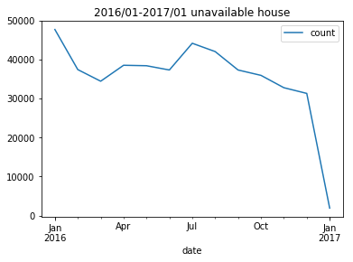

```python
df_f_list.plot(title='2016/01-2017/01 unavailable house')
```

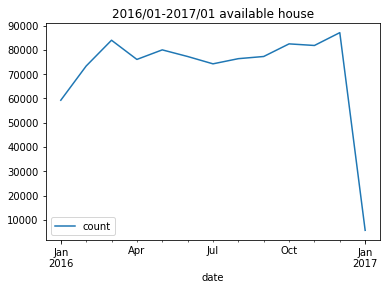

```python
df_t_list.plot(title='2016/01-2017/01 available house')
```

```python
merge_pd = df_settle_clendar_raw.dropna().merge(df_settle_listings_raw,left_on='listing_id',right_on='id',how='inner')
merge_pd.head()
```

|  | listing_id | date | available | price_x | id | listing_url | scrape_id | last_scraped | name | summary | ... | review_scores_value | requires_license | license | jurisdiction_names | instant_bookable | cancellation_policy | require_guest_profile_picture | require_guest_phone_verification | calculated_host_listings_count | reviews_per_month |
| --- | --- | --- | --- | --- | --- | --- | --- | --- | --- | --- | --- | --- | --- | --- | --- | --- | --- | --- | --- | --- | --- |
| 0 | 241032 | 2016-01-04 | t | $85.00 | 241032 | https://www.airbnb.com/rooms/241032 | 20160104002432 | 2016-01-04 | Stylish Queen Anne Apartment | NaN | ... | 10.0 | f | NaN | WASHINGTON | f | moderate | f | f | 2 | 4.07 |
| 1 | 241032 | 2016-01-05 | t | $85.00 | 241032 | https://www.airbnb.com/rooms/241032 | 20160104002432 | 2016-01-04 | Stylish Queen Anne Apartment | NaN | ... | 10.0 | f | NaN | WASHINGTON | f | moderate | f | f | 2 | 4.07 |
| 2 | 241032 | 2016-01-13 | t | $85.00 | 241032 | https://www.airbnb.com/rooms/241032 | 20160104002432 | 2016-01-04 | Stylish Queen Anne Apartment | NaN | ... | 10.0 | f | NaN | WASHINGTON | f | moderate | f | f | 2 | 4.07 |
| 3 | 241032 | 2016-01-14 | t | $85.00 | 241032 | https://www.airbnb.com/rooms/241032 | 20160104002432 | 2016-01-04 | Stylish Queen Anne Apartment | NaN | ... | 10.0 | f | NaN | WASHINGTON | f | moderate | f | f | 2 | 4.07 |
| 4 | 241032 | 2016-01-18 | t | $85.00 | 241032 | https://www.airbnb.com/rooms/241032 | 20160104002432 | 2016-01-04 | Stylish Queen Anne Apartment | NaN | ... | 10.0 | f | NaN | WASHINGTON | f | moderate | f | f | 2 | 4.07 |

5 rows × 96 columns

```python
def get_NaN_feature_names(df)->None:
    """
    get feature have NaN values

    :param df:dataframe
    :return: None
    """
    nan_list =[col_name for col_name in df.columns if df[col_name].isnull().sum() > 0]
    print(nan_list)
get_NaN_feature_names(df_settle_listings_raw)
```

```
['summary', 'space', 'neighborhood_overview', 'notes', 'transit', 'thumbnail_url', 'medium_url', 'xl_picture_url', 'host_name', 'host_since', 'host_location', 'host_about', 'host_response_time', 'host_response_rate', 'host_acceptance_rate', 'host_is_superhost', 'host_thumbnail_url', 'host_picture_ur…
```

#### features have NaN values:

- 'summary', 'space', 'neighborhood_overview', 'notes', 'transit', 'thumbnail_url',
- 'medium_url', 'xl_picture_url', 'host_name', 'host_since', 'host_location', 'host_about',
- 'host_response_time', 'host_response_rate', 'host_acceptance_rate', 'host_is_superhost',
- 'host_thumbnail_url', 'host_picture_url', 'host_neighbourhood', 'host_listings_count',
- 'host_total_listings_count', 'host_has_profile_pic', 'host_identity_verified', 'neighbourhood',
- 'zipcode', 'property_type', 'bathrooms', 'bedrooms', 'beds', 'square_feet', 'weekly_price',
- 'monthly_price', 'security_deposit', 'cleaning_fee', 'first_review', 'last_review',
- 'review_scores_rating', 'review_scores_accuracy', 'review_scores_cleanliness', 'review_scores_checkin',
- 'review_scores_communication', 'review_scores_location', 'review_scores_value', 'license', 'reviews_per_month'

### which feature need to drop or replace ?

1. host_name
2. host_location
3. host_is_superhost
4. property_type
5. bathrooms
6. bedrooms
7. beds
8. square_feet
9. security_deposit
10. cleaning_fee
11. first_review
12. last_review
13. review_scores_rating
14. review_scores_accuracy
15. review_scores_cleanliness
16. review_scores_checkin
17. review_scores_communication
18. review_scores_location
19. review_scores_value
20. license

```python
## replace NaN features
df_settle_listings_raw['host_is_superhost'].replace(['f', 't', np.NaN], [0, 1, 0], inplace = True)
df_settle_listings_raw['cleaning_fee'].replace([np.NaN], [0], inplace = True)
df_settle_listings_raw['bathrooms'].replace([np.NaN], [0], inplace = True)
df_settle_listings_raw['bedrooms'].replace([np.NaN], [0], inplace = True)
df_settle_listings_raw['security_deposit'].replace([np.NaN], [0], inplace = True)

## drop NaN features
df_settle_listings_raw.dropna(subset=['host_name','host_location','property_type',
                                      'beds','first_review','last_review',
                                      'review_scores_rating','review_scores_accuracy','review_scores_cleanliness',
                                      'review_scores_checkin','review_scores_communication','review_scores_location',
                                      'review_scores_value'],how='any',inplace=True)
df_settle_listings_raw.drop(['license','square_feet'], axis = 1, inplace = True)
```

## explore Boston data

### df_boston_airbnb_listings_raw:

```python
get_NaN_feature_names(df_boston_airbnb_listings_raw)
```

```
['summary', 'space', 'neighborhood_overview', 'notes', 'transit', 'access', 'interaction', 'house_rules', 'thumbnail_url', 'medium_url', 'xl_picture_url', 'host_location', 'host_about', 'host_response_time', 'host_response_rate', 'host_acceptance_rate', 'host_neighbourhood', 'neighbourhood', 'neighb…
```

#### We need to drop or replace NaN as df_settle_listings_raw do!

```python
# drop NaN feature
df_boston_airbnb_listings_raw.dropna(subset=['host_location','city','zipcode','market','property_type',
                                            'beds','first_review','last_review','review_scores_rating',
                                            'review_scores_accuracy','review_scores_cleanliness','review_scores_checkin',
                                            'review_scores_communication','review_scores_location','review_scores_value'],how='any',inplace=True)
df_boston_airbnb_listings_raw.drop(['license','jurisdiction_names','neighbourhood','neighbourhood_group_cleansed','square_feet','has_availability'], axis = 1, inplace = True)
# replace NaN feature
df_boston_airbnb_listings_raw['bathrooms'].replace([np.NaN], [0], inplace = True)
df_boston_airbnb_listings_raw['bedrooms'].replace([np.NaN], [0], inplace = True)
df_boston_airbnb_listings_raw['security_deposit'].replace([np.NaN], [0], inplace = True)
df_boston_airbnb_listings_raw['cleaning_fee'].replace([np.NaN], [0], inplace = True)
```

```python
df_boston_airbnb_reviews_raw.isnull().sum()
```

```
listing_id        0
id                0
date              0
reviewer_id       0
reviewer_name     0
comments         53
dtype: int64
```

## Question 1: Is there any relationship between 'price' and 'review_score_rate'?

```python
feature_list = ['id', 'city', 'price', 'security_deposit', 'review_scores_rating',
                'review_scores_accuracy', 'review_scores_cleanliness', 'review_scores_checkin',
                'review_scores_communication', 'review_scores_location', 'review_scores_value']
df_seattle = df_settle_listings_raw[feature_list]
df_boston = df_boston_airbnb_listings_raw[feature_list]

df_seattle.head()
```

|  | id | city | price | security_deposit | review_scores_rating | review_scores_accuracy | review_scores_cleanliness | review_scores_checkin | review_scores_communication | review_scores_location | review_scores_value |
| --- | --- | --- | --- | --- | --- | --- | --- | --- | --- | --- | --- |
| 0 | 241032 | Seattle | $85.00 | 0 | 95.0 | 10.0 | 10.0 | 10.0 | 10.0 | 9.0 | 10.0 |
| 1 | 953595 | Seattle | $150.00 | $100.00 | 96.0 | 10.0 | 10.0 | 10.0 | 10.0 | 10.0 | 10.0 |
| 2 | 3308979 | Seattle | $975.00 | $1,000.00 | 97.0 | 10.0 | 10.0 | 10.0 | 10.0 | 10.0 | 10.0 |
| 4 | 278830 | Seattle | $450.00 | $700.00 | 92.0 | 9.0 | 9.0 | 10.0 | 10.0 | 9.0 | 9.0 |
| 5 | 5956968 | Seattle | $120.00 | 0 | 95.0 | 10.0 | 10.0 | 10.0 | 10.0 | 10.0 | 10.0 |

```python
df_boston.head()
```

|  | id | city | price | security_deposit | review_scores_rating | review_scores_accuracy | review_scores_cleanliness | review_scores_checkin | review_scores_communication | review_scores_location | review_scores_value |
| --- | --- | --- | --- | --- | --- | --- | --- | --- | --- | --- | --- |
| 1 | 3075044 | Boston | $65.00 | $95.00 | 94.0 | 10.0 | 9.0 | 10.0 | 10.0 | 9.0 | 9.0 |
| 2 | 6976 | Boston | $65.00 | 0 | 98.0 | 10.0 | 9.0 | 10.0 | 10.0 | 9.0 | 10.0 |
| 4 | 7651065 | Boston | $79.00 | 0 | 99.0 | 10.0 | 10.0 | 10.0 | 10.0 | 9.0 | 10.0 |
| 5 | 12386020 | Boston | $75.00 | 0 | 100.0 | 10.0 | 10.0 | 10.0 | 10.0 | 9.0 | 10.0 |
| 6 | 5706985 | Boston | $100.00 | 0 | 90.0 | 10.0 | 10.0 | 10.0 | 10.0 | 9.0 | 9.0 |

```python
def trans_price(df_input):
    """
    convert price,security_deposit to float
    :param df_input: dataframe
    :return: dataframe
    """
    df_input['price'] = pd.to_numeric(df_input['price'].replace(r'\$', '', regex = True).replace(r',', '', regex = True))
    df_input['security_deposit'] = pd.to_numeric(df_input['security_deposit'].replace(r'\$', '', regex = True).replace(r',', '', regex = True))
    return df_input

df_settle = trans_price(df_seattle)
df_settle.head()
```

|  | id | city | price | security_deposit | review_scores_rating | review_scores_accuracy | review_scores_cleanliness | review_scores_checkin | review_scores_communication | review_scores_location | review_scores_value |
| --- | --- | --- | --- | --- | --- | --- | --- | --- | --- | --- | --- |
| 0 | 241032 | Seattle | 85.0 | 0.0 | 95.0 | 10.0 | 10.0 | 10.0 | 10.0 | 9.0 | 10.0 |
| 1 | 953595 | Seattle | 150.0 | 100.0 | 96.0 | 10.0 | 10.0 | 10.0 | 10.0 | 10.0 | 10.0 |
| 2 | 3308979 | Seattle | 975.0 | 1000.0 | 97.0 | 10.0 | 10.0 | 10.0 | 10.0 | 10.0 | 10.0 |
| 4 | 278830 | Seattle | 450.0 | 700.0 | 92.0 | 9.0 | 9.0 | 10.0 | 10.0 | 9.0 | 9.0 |
| 5 | 5956968 | Seattle | 120.0 | 0.0 | 95.0 | 10.0 | 10.0 | 10.0 | 10.0 | 10.0 | 10.0 |

```python
df_boston = trans_price(df_boston)
df_boston.head()
```

|  | id | city | price | security_deposit | review_scores_rating | review_scores_accuracy | review_scores_cleanliness | review_scores_checkin | review_scores_communication | review_scores_location | review_scores_value |
| --- | --- | --- | --- | --- | --- | --- | --- | --- | --- | --- | --- |
| 1 | 3075044 | Boston | 65.0 | 95.0 | 94.0 | 10.0 | 9.0 | 10.0 | 10.0 | 9.0 | 9.0 |
| 2 | 6976 | Boston | 65.0 | 0.0 | 98.0 | 10.0 | 9.0 | 10.0 | 10.0 | 9.0 | 10.0 |
| 4 | 7651065 | Boston | 79.0 | 0.0 | 99.0 | 10.0 | 10.0 | 10.0 | 10.0 | 9.0 | 10.0 |
| 5 | 12386020 | Boston | 75.0 | 0.0 | 100.0 | 10.0 | 10.0 | 10.0 | 10.0 | 9.0 | 10.0 |
| 6 | 5706985 | Boston | 100.0 | 0.0 | 90.0 | 10.0 | 10.0 | 10.0 | 10.0 | 9.0 | 9.0 |

```python
## check data type
df_seattle.info()
```

```
<class 'pandas.core.frame.DataFrame'>
Int64Index: 3158 entries, 0 to 3814
Data columns (total 11 columns):
id                             3158 non-null int64
city                           3158 non-null object
price                          3158 non-null float64
security_deposit               3158 non-null float64
review_scores_rating           3158 non-null float64
review_scores_accuracy         3158 non-null float64
review_scores_cleanliness      3158 non-null float64
review_scores_checkin          3158 non-null float64
review_scores_communication    3158 non-null float64
review_scores_location         3158 non-null float64
review_scores_value            3158 non-null float64
dtypes: float64(9), int64(1), object(1)
memory usage: 296.1+ KB
```

```python
df_sum = np.sum(df_seattle['price'])
df_sum
```

```
400826.0
```

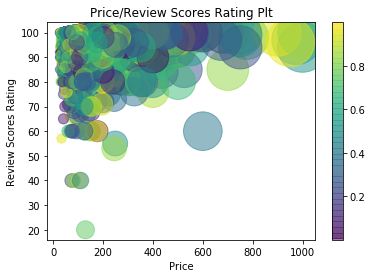

```python
## plot
df_sum = np.sum(df_seattle['price'])
rng = np.random.RandomState(0)
colors = rng.rand(df_seattle['price'].shape[0])
sizes = 1000000 * df_seattle['price']/df_sum

plt.scatter(df_seattle['price'], df_seattle['review_scores_rating'],marker='o',c=colors,s=sizes,alpha=0.5,cmap='viridis')
plt.xlabel('Price')
plt.ylabel('Review Scores Rating')
plt.colorbar()
plt.title('Price/Review Scores Rating Plt')
plt.show()
```

## Data Modeling Question 2

At this session,we try to find out some patterns between 'price' and other's 'scores'.I removed columns like 'id',and 'city' from the data,because them are unnecessary.We use a loop to plot the scatter between the price and any other score features.

### Question 2:Is there any pattern between other scores with price ?

```python
#remove some columns,which are not required.
feature_plt = feature_list
feature_plt.remove('id')
feature_plt.remove('city')
feature_plt
```

```
['price',
 'security_deposit',
 'review_scores_rating',
 'review_scores_accuracy',
 'review_scores_cleanliness',
 'review_scores_checkin',
 'review_scores_communication',
 'review_scores_location',
 'review_scores_value']
```

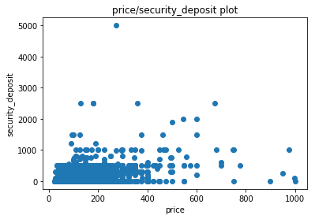

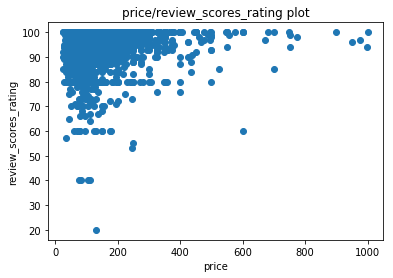

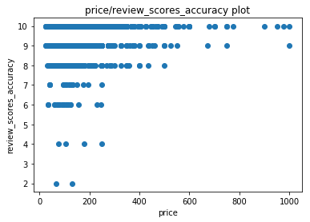

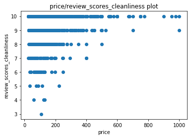

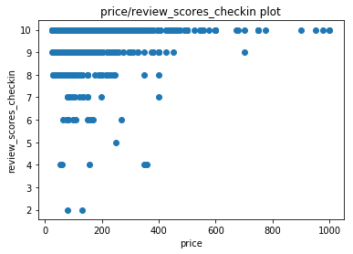

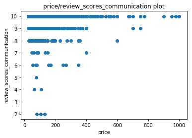

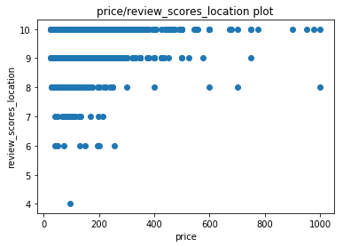

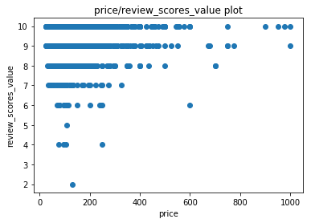

```python
# plot
max_val = len(feature_plt)
for f1 in range(max_val):
    for f2 in range(f1 + 1, max_val):
        plt.scatter(df_seattle[feature_plt[f1]], df_seattle[feature_plt[f2]])
        plt.xlabel(feature_plt[f1])
        plt.ylabel(feature_plt[f2])
        plt.title('{}/{} plot'.format(feature_plt[f1], feature_plt[f2]))
        plt.show()

    break
```

### Answer Q2

From the plot image,all the features are between the 'price' and 'scores', It seems like there's only price/security_deposit plot have effects with others.From the plot of price/security_deposit,it seems that not have any relationship with 'price'.Perhaps the expensive price houses were not care about the security_deposit,they face to higher level's consumers.

## Data Modeling Question 3

At this section, we will try to find some pattern about the location and the price.

### Question 3:Is there any pattern between the location and the price?

```python
## from 'country','price' columns，find out some relationships
df_seattle = df_seattle[['city', 'price']]
df_boston = df_boston[['city', 'price']]

df_seattle['city'].replace(['Ballard, Seattle', 'Seattle ', '西雅图'],
                           ['Ballard Seattle', 'Seattle', 'Seattle'], inplace = True)
set(df_seattle['city'])
```

```
{'Ballard Seattle', 'Phinney Ridge Seattle', 'Seattle', 'West Seattle'}
```

```python
## we need to transfer data,because they have different name,but means the same place.
df_boston['city'].replace(['ALLSTON', 'Boston ', 'Boston (Charlestown)', 'Boston (Jamaica Plain)',
                          'Brighton ', 'Jamaica Plain ', 'Jamaica Plain (Boston)', 'Jamaica Plain, Boston',
                          'Jamaica Plain, MA', 'Mission Hill, Boston', 'ROXBURY CROSSING', 'Roslindale, Boston',
                          'boston', 'dorchester, boston ', 'east Boston '],
                           ['Allston', 'Boston', 'Charlestown', 'Jamaica Plain',
                           'Brighton', 'Jamaica Plain', 'Jamaica Plain', 'Jamaica Plain',
                           'Jamaica Plain', 'Mission Hill', 'Roxbury Crossing', 'Roslindale',
                           'Boston', 'Dorchester', 'East Boston'], inplace = True)
set(df_boston['city'])
```

```
{'Allston',
 'Boston',
 'Brighton',
 'Brookline',
 'Cambridge',
 'Charlestown',
 'Dorchester',
 'East Boston',
 'Hyde Park',
 'Jamaica Plain',
 'Mattapan',
 'Milton',
 'Mission Hill',
 'Roslindale',
 'Roxbury Crossing',
 'Somerville',
 'South Boston',
 'South End, Boston',
 'West Roxbury'}
```

```python
# One hot
city_dict = {}
val = 0
for city in set(df_seattle.city.values):
    city_dict[city] = val
    val += 1

for city in set(df_boston.city.values):
    city_dict[city] = val
    val += 1

city_dict
```

```
{'Seattle': 0,
 'Ballard Seattle': 1,
 'Phinney Ridge Seattle': 2,
 'West Seattle': 3,
 'Mission Hill': 4,
 'Allston': 5,
 'Roslindale': 6,
 'Roxbury Crossing': 7,
 'Somerville': 8,
 'Brighton': 9,
 'East Boston': 10,
 'West Roxbury': 11,
 'Mattapan': 12,
 'Hyde Park': 13,
 'Milton': 14,
 'Dorchester': 15,
 'Boston': 16,
 'Brookline': 17,
 'South Boston': 18,
 'Charlestown': 19,
 'Cambridge': 20,
 'Jamaica Plain': 21,
 'South End, Boston': 22}
```

```python
df_data = pd.concat([df_seattle,df_boston],ignore_index=True)
df_data.replace(city_dict,inplace=True)
df_data.head()
```

|  | city | price |
| --- | --- | --- |
| 0 | 0 | 85.0 |
| 1 | 0 | 150.0 |
| 2 | 0 | 975.0 |
| 3 | 0 | 450.0 |
| 4 | 0 | 120.0 |

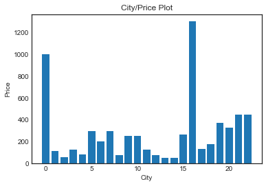

```python
## plot use bar model
plt.style.use('seaborn-white')
plt.bar(df_data['city'],df_data['price'])
plt.xlabel('City')
plt.ylabel('Price')
plt.title('City/Price Plot')
plt.show()
```